# Small-sample interval coverage and model-selection optimism: two reproducible simulation studies

Satvik Praveen

27 September 2026

# Abstract

We report two Monte Carlo experiments, designed and reported according to the ADEMP framework (Morris et al. 2019), using the `RDataScienceCompendium` R package. **Study 1** compares five nominal 95% confidence intervals for the mean of log-normal data. The Student $t$ interval had the best coverage for mild to moderate skew at every sample size studied. With strong skew ($\sigma = 1$), all intervals under-covered: at $n = 10$ coverage ranged from 77.2% (basic bootstrap) to 84.3%. The BCa interval was the best or joint-best bootstrap method in every scenario with strong skew. **Study 2** shows that reporting the cross-validated error of the best-performing candidate model is optimistically biased. The bias was largest with small samples and many candidates: at $n = 50$ with 25 noise candidates, the true RMSE was understated by 0.107 on average. Nested cross-validation removed the selection bias, but only when the RMSE was computed from the pooled out-of-fold predictions. Averaging per-fold RMSEs, which is common practice, left a residual optimism of up to 0.017 caused by Jensen’s inequality. All results carry Monte Carlo standard errors (MCSEs) and can be regenerated with a single command.

# 1 Introduction

Resampling methods are often recommended because they relax distributional assumptions. Whether they deliver on this promise at the sample sizes seen in practice is an empirical question, and simulation studies are the standard tool for answering it. Simulation studies are experiments, however, and their conclusions are only as reliable as their design and their quantification of Monte Carlo error (Morris et al. 2019).

We study two questions that come up routinely in applied work:

1. Do bootstrap confidence intervals for a mean improve on the $t$ interval when the data are skewed and $n$ is small (Efron 1987; Davison and Hinkley 1997)?
2. How optimistic is it to report the cross-validation (CV) error of the model that was *chosen* by that same CV, and does nested CV fix this (Varma and Simon 2006; Cawley and Talbot 2010)?

# 2 Methods

All computations use the `RDataScienceCompendium` package (version 0.2.0). Each (scenario, replicate) pair has its own L’Ecuyer-CMRG random-number stream (L’Ecuyer et al. 2002), so results do not depend on how many parallel workers are used. The seeds and run times are listed in the provenance files in `analysis/results/`.

## 2.1 Study 1: interval coverage under skewness

| ADEMP | Specification |
| --- | --- |
| **Aims** | Compare coverage and width of five nominal 95% intervals for a mean. |
| **Data-generating mechanisms** | $X_i \sim \mathrm{LogNormal}(0, \sigma^2)$, $n \in \{10, 20, 40, 80\}$, $\sigma \in \{0.25, 0.5, 1\}$ (skewness 0.78, 1.75, 6.18); full factorial, 12 scenarios. |
| **Estimand** | $\theta = E[X] = \exp(\sigma^2/2)$. |
| **Methods** | Student $t$; nonparametric bootstrap percentile, basic, normal and BCa intervals with $R = 1999$ resamples. |
| **Performance measures** | Coverage (primary), bias-eliminated coverage, mean width. |
| **Replicates** | 5000 per scenario, so that coverage MCSE $\le 0.31$ percentage points near 95%. The largest observed coverage MCSE was 0.59 points. |

## 2.2 Study 2: optimism after model selection by cross-validation

[output not shown]

Nested CV estimates the error of the procedure when it is trained on 80% of the data. It is therefore expected to be slightly *pessimistic* about a model trained on all $n$ observations. We added the pooled variants after a pilot run showed nested CV to be unexpectedly *optimistic*. Our hypothesis was that averaging square roots of per-fold mean squared errors is biased downwards when test folds are small, since $E[\sqrt{\widehat{\mathrm{MSE}}}] \le \sqrt{E[\widehat{\mathrm{MSE}}]}$. The pooled variants test this hypothesis directly.

# 3 Results

No replicate failed in either study (0 and 0 failures).

## 3.1 Study 1

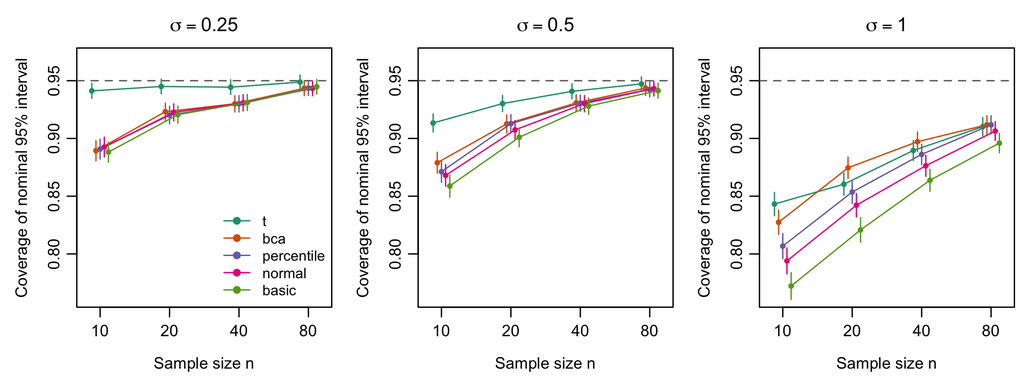

Figure 1. Coverage of nominal 95% intervals for a log-normal mean. Bars are ±1.96 MCSE.

Table 1. Coverage, % (MCSE), of nominal 95% intervals.

| sigma | n | t | bca | percentile | normal | basic |
| --- | --- | --- | --- | --- | --- | --- |
| 0.25 | 10 | 94.1 (0.3) | 88.9 (0.4) | 89.1 (0.4) | 89.3 (0.4) | 88.8 (0.4) |
| 0.25 | 20 | 94.5 (0.3) | 92.3 (0.4) | 92.0 (0.4) | 92.3 (0.4) | 92.1 (0.4) |
| 0.25 | 40 | 94.4 (0.3) | 93.0 (0.4) | 93.0 (0.4) | 93.1 (0.4) | 93.1 (0.4) |
| 0.25 | 80 | 94.9 (0.3) | 94.3 (0.3) | 94.4 (0.3) | 94.3 (0.3) | 94.5 (0.3) |
| 0.50 | 10 | 91.3 (0.4) | 87.9 (0.5) | 87.1 (0.5) | 86.8 (0.5) | 85.9 (0.5) |
| 0.50 | 20 | 93.0 (0.4) | 91.3 (0.4) | 91.3 (0.4) | 90.7 (0.4) | 90.1 (0.4) |
| 0.50 | 40 | 94.1 (0.3) | 93.1 (0.4) | 93.1 (0.4) | 93.0 (0.4) | 92.8 (0.4) |
| 0.50 | 80 | 94.7 (0.3) | 94.4 (0.3) | 94.2 (0.3) | 94.3 (0.3) | 94.1 (0.3) |
| 1.00 | 10 | 84.3 (0.5) | 82.7 (0.5) | 80.7 (0.6) | 79.4 (0.6) | 77.2 (0.6) |
| 1.00 | 20 | 86.0 (0.5) | 87.5 (0.5) | 85.4 (0.5) | 84.2 (0.5) | 82.1 (0.5) |
| 1.00 | 40 | 89.0 (0.4) | 89.7 (0.4) | 88.6 (0.4) | 87.6 (0.5) | 86.4 (0.5) |
| 1.00 | 80 | 91.0 (0.4) | 91.2 (0.4) | 91.2 (0.4) | 90.6 (0.4) | 89.6 (0.4) |

Table 2. Mean interval width at n = 20.

| sigma | t | bca | percentile | normal | basic |
| --- | --- | --- | --- | --- | --- |
| 0.25 | 0.241 | 0.223 | 0.220 | 0.220 | 0.220 |
| 0.50 | 0.546 | 0.521 | 0.497 | 0.498 | 0.497 |
| 1.00 | 1.714 | 1.781 | 1.532 | 1.564 | 1.532 |

## 3.2 Study 2

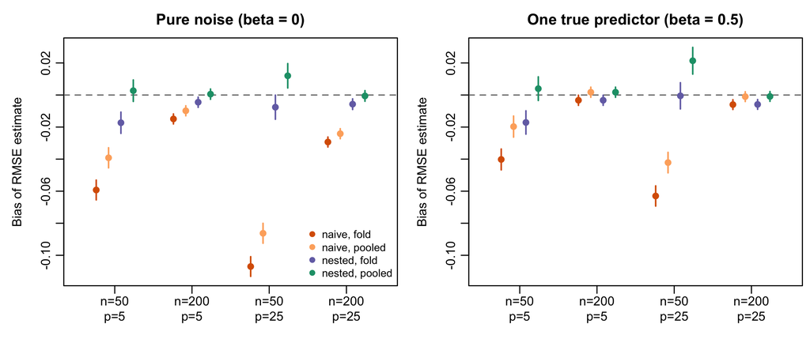

Figure 2. Bias of the naive and nested CV estimates of the final model’s RMSE. Bars are ±1.96 MCSE.

Table 3. Bias (MCSE) of CV estimates of the final model’s RMSE, and how often the true predictor was selected.

| beta | n | p | naive, fold | naive, pooled | nested, fold | nested, pooled | P(select x1) |
| --- | --- | --- | --- | --- | --- | --- | --- |
| 0.0 | 50 | 5 | -0.059 (0.003) | -0.039 (0.003) | -0.017 (0.003) | +0.003 (0.003) | — |
| 0.0 | 200 | 5 | -0.015 (0.002) | -0.010 (0.002) | -0.004 (0.002) | +0.001 (0.002) | — |
| 0.0 | 50 | 25 | -0.107 (0.003) | -0.086 (0.003) | -0.008 (0.004) | +0.012 (0.004) | — |
| 0.0 | 200 | 25 | -0.029 (0.002) | -0.024 (0.002) | -0.006 (0.002) | -0.001 (0.002) | — |
| 0.5 | 50 | 5 | -0.040 (0.003) | -0.020 (0.003) | -0.017 (0.004) | +0.004 (0.004) | 91% |
| 0.5 | 200 | 5 | -0.003 (0.002) | +0.002 (0.002) | -0.003 (0.002) | +0.002 (0.002) | 100% |
| 0.5 | 50 | 25 | -0.063 (0.003) | -0.042 (0.003) | -0.001 (0.004) | +0.021 (0.004) | 79% |
| 0.5 | 200 | 25 | -0.006 (0.002) | -0.001 (0.002) | -0.006 (0.002) | -0.001 (0.002) | 100% |

**Selection bias.** The naive estimate was optimistic in every scenario where the choice among candidates was not obvious, under both aggregations. Its bias grew with the number of candidates and shrank with $n$. Under the null, pooled naive bias went from -0.010 (MCSE 0.002) at $n = 200, p = 5$ to -0.086 (MCSE 0.003) at $n = 50, p = 25$. When a real signal was present and $n = 200$, the true predictor was always selected and the optimism essentially vanished (-0.001 (MCSE 0.002)).

**Aggregation bias.** The fold-averaged nested estimate was also optimistic, for example -0.017 (MCSE 0.003) at $n = 50, p = 5$. Pooling removed this bias (0.003 (MCSE 0.003)). This is consistent with it being an artefact of averaging per-fold RMSEs and not a failure of nested CV. With pooling, nested CV had 6 of 8 biases within 2 MCSE of zero. The exceptions were small and *positive*, at most +0.021. That is the expected pessimism from training on 80% of the data, and it is largest when $n = 50$ and there are many candidates to choose from.

# 4 Discussion

In Study 1 the bootstrap offered no advantage over the $t$ interval for the mean at small $n$ and moderate skew. For strongly skewed data, BCa was the best bootstrap interval and overtook $t$ as $n$ grew. No method was satisfactory at $n = 10$ with heavy skew. This agrees with the theoretical second-order accuracy of BCa, and with its known small-sample narrowness (Efron 1987; Davison and Hinkley 1997). The practical lesson is to present small-sample intervals for skewed data with appropriate caution, not to choose the bootstrap by default.

**Limitations.** Study 1 considers only log-normal data and the mean; heavier tails or other statistics may favour different methods. Study 2 uses a simple class of candidate models and a single choice of fold counts. Both designs are easy to extend with the scripts provided.

# Reproducibility

From the repository root:

```bash
make analysis   # install package, run both studies, draw figures, render paper
```

The studies used a machine with future backend and took 123.6 s (Study 1) and 388.2 s (Study 2) of wall-clock time on aarch64-apple-darwin25.2.0 running R version 4.5.2 (2025-10-31). Because every replicate has its own random-number stream, the numbers in this paper are reproduced exactly with any number of workers (`RDSC_WORKERS=1` for a sequential run).

# References

Cawley, Gavin C., and Nicola L. C. Talbot. 2010. “On over-Fitting in Model Selection and Subsequent Selection Bias in Performance Evaluation.” *Journal of Machine Learning Research* 11: 2079–107.

Davison, A. C., and D. V. Hinkley. 1997. *Bootstrap Methods and Their Application*. Cambridge University Press. https://doi.org/10.1017/CBO9780511802843.

Efron, Bradley. 1987. “Better Bootstrap Confidence Intervals.” *Journal of the American Statistical Association* 82 (397): 171–85. https://doi.org/10.1080/01621459.1987.10478410.

Forman, George, and Martin Scholz. 2010. “Apples-to-Apples in Cross-Validation Studies: Pitfalls in Classifier Performance Measurement.” *ACM SIGKDD Explorations Newsletter* 12 (1): 49–57. https://doi.org/10.1145/1882471.1882479.

L’Ecuyer, Pierre, Richard Simard, E. Jack Chen, and W. David Kelton. 2002. “An Object-Oriented Random-Number Package with Many Long Streams and Substreams.” *Operations Research* 50 (6): 1073–75. https://doi.org/10.1287/opre.50.6.1073.358.

Morris, Tim P., Ian R. White, and Michael J. Crowther. 2019. “Using Simulation Studies to Evaluate Statistical Methods.” *Statistics in Medicine* 38 (11): 2074–102. https://doi.org/10.1002/sim.8086.

Varma, Sudhir, and Richard Simon. 2006. “Bias in Error Estimation When Using Cross-Validation for Model Selection.” *BMC Bioinformatics* 7: 91. https://doi.org/10.1186/1471-2105-7-91.